# measure variable responces of continuous feature with DALEX + mlr

Satoshi Kato

2019/02/20

# read mlr models

regression task for apartments dataset.

```r
tuned.model <- readRDS("./tuned_models.RDS")
# tuned.model %>% str(2)
```

# DALEX + mlr

according to:

https://rawgit.com/pbiecek/DALEX_docs/master/vignettes/DALEX_mlr.html

# The explain() function

## custom predict()

For the models created by mlr package we have to provide custom predict function which takes two arguments: model and newdata and returns a numeric vector with predictions because function predict() from mlr returns not only predictions but an object with more information.

```r
predictMLR <- function(object, newdata) {
  pred <- predict(object, newdata=newdata)
  response <- pred$data$response
  return(response)
}
```

# build explainer

## simple

```r
require(DALEX)
data("apartmentsTest", package = "DALEX")

model.regr.rf <- tuned.model[["rf"]]

explainer <- list()
explainer.rf <-  explain(model = model.regr.rf,
                         label = "rf",
                         data  = apartmentsTest %>% select(-m2.price),
                         y     = apartmentsTest$m2.price,
                         predict_function = predictMLR)
```

## multiple explainers

```r
model.labels <- names(tuned.model)
model.regr   <- list()

for(model.name in model.labels){
  model.regr[[model.name]] <- tuned.model[[model.name]]

  explainer[[model.name]] <- explain(model = model.regr[[model.name]],
                                     label = model.name,
                                     data  = apartmentsTest %>% select(-m2.price),
                                     y     = apartmentsTest$m2.price,
                                     predict_function = predictMLR)
}
```

# Variable response

Explainers presented in this section are designed to better understand the relation between a variable and model output.

For more details of methods desribed in this section see Variable response section in DALEX docs.

## ceteris paribus plot

```r
install.packages("ceterisParibus", dependencies = TRUE)
```

```r
library("ceterisParibus")
```

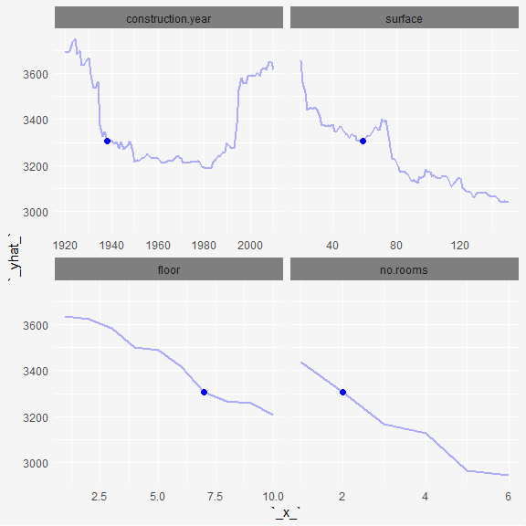

```r
single.instance <- apartmentsTest[7, ]
profile_rf <- ceteris_paribus(explainer.rf,
                              observations = single.instance)
plot(profile_rf, color = "blue")
```